# 第8講 確率分布

いろいろな離散分布と連続分布

Published

June 3, 2026

## 準備

以下で利用する共通パッケージを読み込む．

```r
library(conflicted)  # 関数名の衝突を警告
conflicts_prefer(    # 優先的に使う関数を指定
    dplyr::filter(),
    dplyr::select(),
    dplyr::lag(),
    )
library(tidyverse)
#' 日本語を用いるので macOS ではフォントの設定を行う
if(Sys.info()["sysname"] == "Darwin") { # macOS か調べて日本語フォントを指定
    theme_update(text = element_text(family = "HiraginoSans-W4"))
    update_geom_defaults("text", list(family = theme_get()$text$family))
    update_geom_defaults("label", list(family = theme_get()$text$family))}
```

## 二項分布

### 問題

二項分布に関して以下を考察せよ．

- 平均と分散の理論計算を確認しなさい．
- $X_{1},\dotsc,X_n$ を成功確率 $p$ の Bernoulli 分布に従う独立同分布な確率変数列とする． このとき $\sum_{i=1}^nX_i$ の分布は，試行回数 $n$ , 成功確率 $p$ の二項分布に従う．これをグラフに描画して確認しなさい．

### 解答欄

### 解答例

試行を模擬する関数を定義する．

```r
n <- 16
p <- 0.6
my_random <- function(){ # Bernoulli分布をm個生成して合計
    sum(rbinom(n, size=1, prob=p))}
```

確率シミュレーションを行う．

```r
mc <- 10000 # 実験回数を指定
my_data <- replicate(mc, my_random())
```

出現値ごとの度数分布表，および正規化した確率表を表示する．

```r
my_data |> table()                 # base::table による頻度表の作成
```

```
my_data
   2    3    4    5    6    7    8    9   10   11   12   13   14   15   16
   1    6   40  133  387  887 1403 1886 2039 1566 1010  454  156   29    3
```

```r
my_data |> table() |> prop.table() # 確率値に変換
```

```
my_data
     2      3      4      5      6      7      8      9     10     11     12
0.0001 0.0006 0.0040 0.0133 0.0387 0.0887 0.1403 0.1886 0.2039 0.1566 0.1010
    13     14     15     16
0.0454 0.0156 0.0029 0.0003
```

`tibble`形式のデータフレームを作成するには関数 `dplyr::count()` を利用して例えば以下のようにすればよい．

```r
my_data |>
    as_tibble_col() |> # ベクトルから1列のtibbleを作成．列名の既定値は value
    count(value)       # value 列の頻度を集計する
```

```
# A tibble: 15 × 2
   value     n
   <int> <int>
 1     2     1
 2     3     6
 3     4    40
 4     5   133
 5     6   387
 6     7   887
 7     8  1403
 8     9  1886
 9    10  2039
10    11  1566
11    12  1010
12    13   454
13    14   156
14    15    29
15    16     3
```

棒グラフを利用して頻度表を視覚化する．

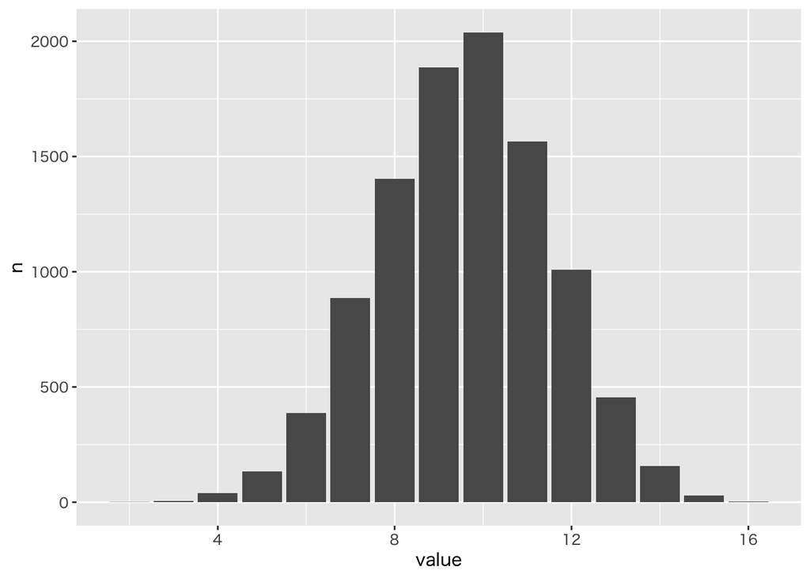

```r
my_data |>
    as_tibble_col() |>              # tibbleに変換
    count(value) |>                 # 頻度の集計
    ggplot(aes(x = value, y = n)) + # 描画の基本設定
    geom_bar(stat = "identity")     # 最も単純な表示
```

理論値(確率)は関数 `dbinom()` で計算できるので，組み合わせて横並びに表示する．

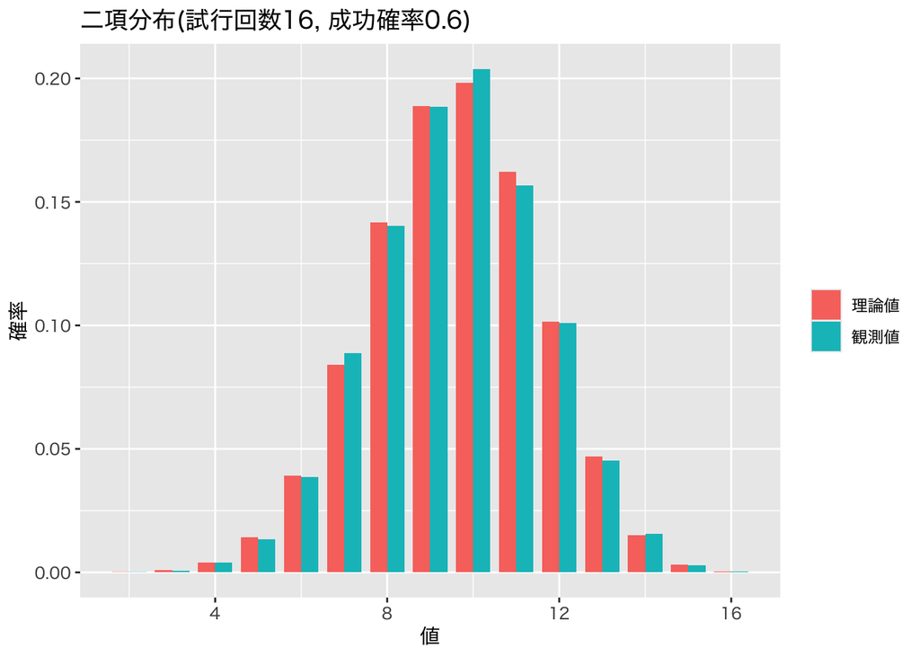

```r
my_data |>
    as_tibble_col() |>
    count(value) |>
    set_names(c("値","観測値")) |>                     # 列名を日本語に変更
    mutate(観測値 = 観測値/sum(観測値),                  # 確率に変換
           理論値 = dbinom(値, size = n, prob = p)) |> # 理論値を追加
    pivot_longer(!値, values_to = "確率") |>           # long formatに変換
    ggplot(aes(x = 値, y = 確率, fill = name)) +       # 描画の基本設定
    geom_bar(stat = "identity",
             width = 0.8,                             # 並びがわかりやすいように幅を調整
             position = "dodge") +
    labs(fill = NULL,                                 # 凡例のfillの名称(name)を消去
         title = paste0("二項分布(試行回数", n, ", 成功確率", p, ")"))
```

上記の例では `dplyr::count` を利用する場合を示したが， 視覚化のためのデータフレームはいろいろな方法で作成できる．

`base::table()` および `base::prop.table()` を利用する場合．

```r
my_table <- my_data |> table() |> prop.table()
tibble(値 = as.integer(names(my_table)),       # 列名は文字列なので整数値に変換(as.numericでも良い)
       観測値 = as.vector(my_table),            # table型をvector型に変換(as.numericでも良い)
       理論値 = dbinom(値, size = n, prob = p)) # 理論値を追加
```

```
# A tibble: 15 × 3
      値 観測値   理論値
   <int>  <dbl>    <dbl>
 1     2 0.0001 0.000116
 2     3 0.0006 0.000812
 3     4 0.004  0.00396
 4     5 0.0133 0.0142
 5     6 0.0387 0.0392
 6     7 0.0887 0.0840
 7     8 0.140  0.142
 8     9 0.189  0.189
 9    10 0.204  0.198
10    11 0.157  0.162
11    12 0.101  0.101
12    13 0.0454 0.0468
13    14 0.0156 0.0150
14    15 0.0029 0.00301
15    16 0.0003 0.000282
```

`package::janitor` を利用する場合．

```r
library(janitor)
my_data |>
    as_tibble_col() |>
    tabyl(value) |>                                # 確率の計算
    set_names(c("値","頻度","観測値")) |>            # 列名を変更
    mutate(理論値 = dbinom(値, size = n, prob = p)) # 理論値を追加
```

```
 値 頻度 観測値       理論値
  2    1 0.0001 0.0001159641
  3    6 0.0006 0.0008117488
  4   40 0.0040 0.0039572755
  5  133 0.0133 0.0142461918
  6  387 0.0387 0.0391770274
  7  887 0.0887 0.0839507729
  8 1403 0.1403 0.1416669293
  9 1886 0.1886 0.1888892391
 10 2039 0.2039 0.1983337011
 11 1566 0.1566 0.1622730282
 12 1010 0.1010 0.1014206426
 13  454 0.0454 0.0468095274
 14  156 0.0156 0.0150459195
 15   29 0.0029 0.0030091839
 16    3 0.0003 0.0002821110
```

## Poisson 分布

### 問題

Poisson 分布に関して以下を考察せよ．

- 平均と分散の理論計算を確認しなさい．
- $X,Y$ を独立な2つの確率変数とし，それぞれ強度 $\lambda_{1},\lambda_{2}$ の Poisson 分布に従うとする． このとき, 和 $X+Y$ の分布は強度 $\lambda_{1}+\lambda_{2}$ の Poisson 分布に従う． これをグラフに描画して確認しなさい．

### 解答欄

### 解答例

試行を模擬する関数を定義する．

```r
lambda1 <- 5
lambda2 <- 12
my_random <- function(){ # 2つの Poisson 分布の和
    rpois(1, lambda=lambda1)+rpois(1, lambda=lambda2)}
```

確率シミュレーションを行ない，視覚化する．

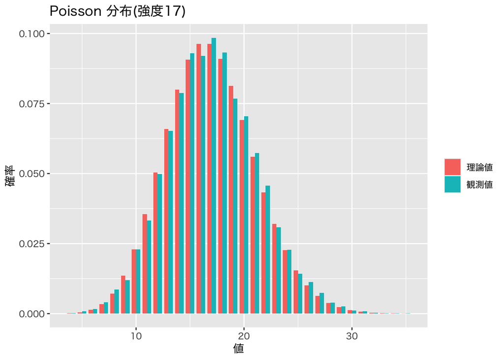

```r
mc <- 10000
my_data <- replicate(mc, my_random())
my_data |> as_tibble_col() |>
    count(value) |>                                      # 頻度を計算
    set_names(c("値","観測値")) |>                        # 列名を変更
    mutate(観測値 = 観測値/sum(観測値),                     # 確率に変換
           理論値 = dpois(値, lambda=lambda1+lambda2)) |> # 理論値を追加
    pivot_longer(!値, values_to = "確率") |>
    ggplot(aes(x = 値, y = 確率, fill = name)) +
    geom_bar(stat = "identity",
             width = 0.8,
             position = "dodge") +
    labs(fill = NULL,
         title = paste0("Poisson 分布(強度", lambda1+lambda2, ")"))
```

## 正規分布

### 問題

正規分布に関して以下を考察せよ．

- $U_{1},U_{2}$ を $(0,1)$ 上の一様分布に従う独立な確率変数とする． このとき
  $$\begin{align}
  X_{1}&=\sqrt{-2\log(U_{1})}\cos(2\pi U_{2}),\\
  X_{2}&=\sqrt{-2\log(U_{1})}\sin(2\pi U_{2})
  \end{align}$$
  とおくと， $X_{1},X_{2}$ は独立かつともに標準正規分布に従う． これをグラフに描画して確認しなさい．

**Note**

この変換を Box-Muller 変換と呼ぶ．

### 解答欄

### 解答例

試行を模擬する関数を作成する．

```r
my_random <- function(){ # 一方の分布を確認する
    u1 <- runif(1)
    u2 <- runif(1)
    return(sqrt(-2*log(u1))*cos(2*pi*u2))}
```

確率シミュレーションを行い，ヒストグラムを用いて視覚化する．

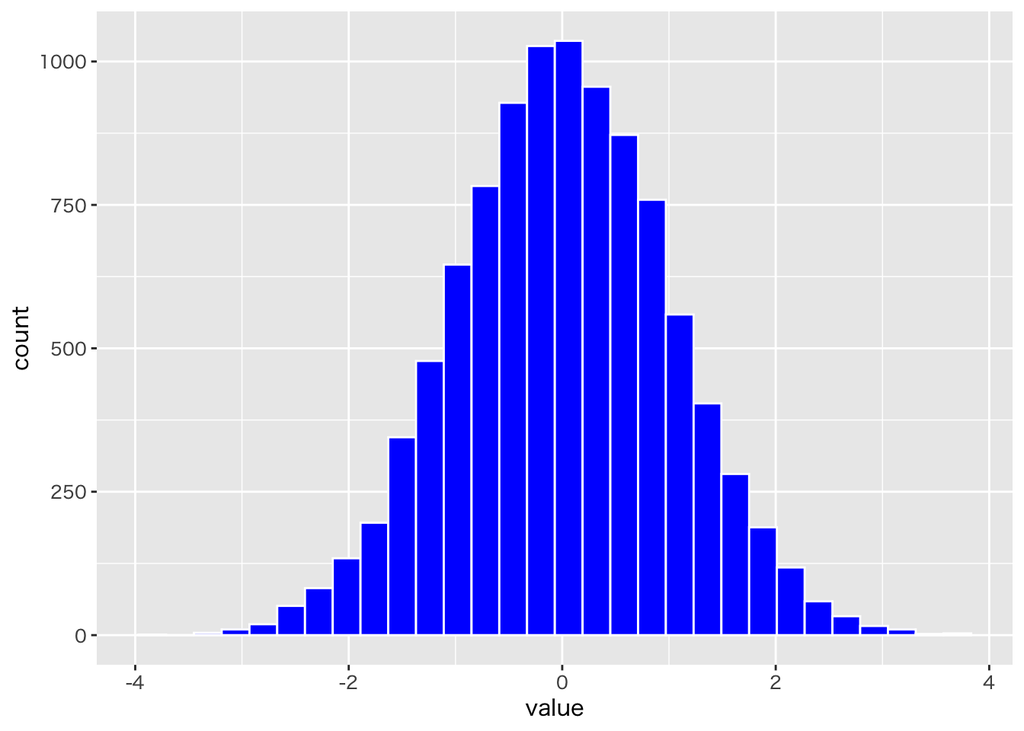

```r
mc <- 10000 # 実験回数を指定
replicate(mc, my_random()) |>        # 確率シミュレーション
    as_tibble_col() |>               # 既定値では列名は value
    ggplot(aes(x = value)) +
    geom_histogram(bins = 30,        # 既定値では頻度で表示される
                   fill ="blue",     # 塗り潰しの色
                   colour = "white") # 外枠の色
```

理論値は関数 `stats::dnorm()` で計算できるので， 関数 `ggplot2::geom_function()` を用いて重ね描きする．

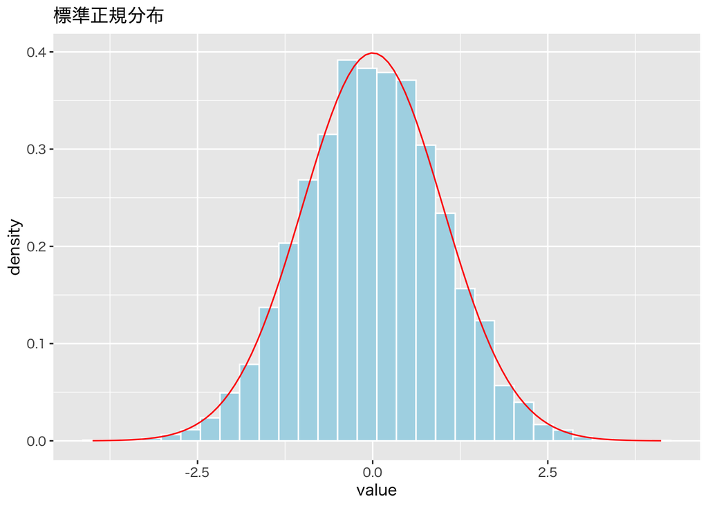

```r
replicate(mc, my_random()) |>
    as_tibble_col() |>
    ggplot(aes(x = value)) +
    geom_histogram(aes(y = after_stat(density)), # 確率で表示
                   bins = 30,
                   fill ="lightblue",
                   colour = "white") +
    geom_function(fun = dnorm,
                  colour = "red") +
    labs(title = "標準正規分布")
```

Box-Muller法で作られる2つの確率変数の関係を調べてみる． それぞれを取り出せるように関数を作成する．

```r
boxmuller <- function(){
    u1 <- runif(1)
    u2 <- runif(1)
    x1 <- sqrt(-2*log(u1))*cos(2*pi*u2)
    x2 <- sqrt(-2*log(u1))*sin(2*pi*u2)
    return(c(x1,x2))
}
```

2つの変数の散布図を描く．

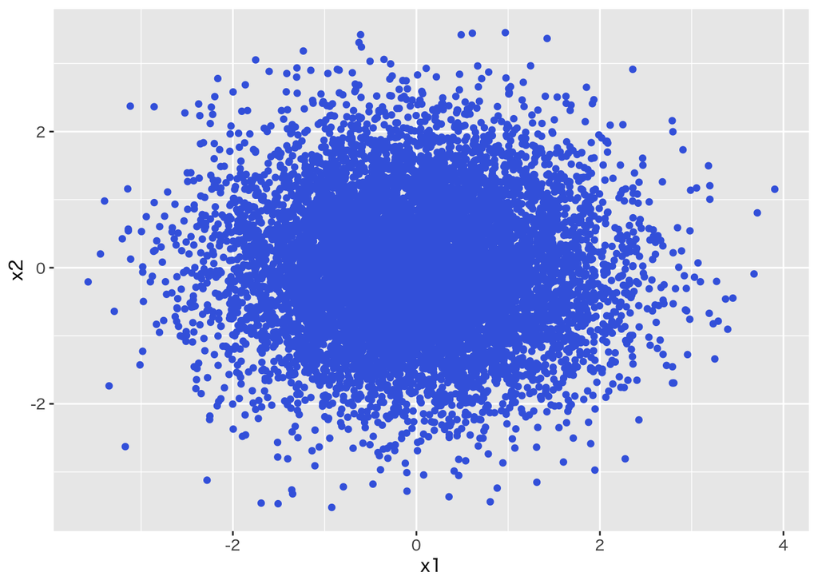

```r
x <- replicate(mc, boxmuller()) # 2行 x mc列の行列が得られる
tibble(x1 = x[1,], x2 = x[2,]) |>
    ggplot(aes(x = x1, y = x2)) +
    geom_point(colour = "royalblue")
```

`x1,x2` は同じ分布に従う独立な変数なので以下ではまとめて扱う． 個別に扱う場合は `x` を `x[1,]` などとすれば良い．

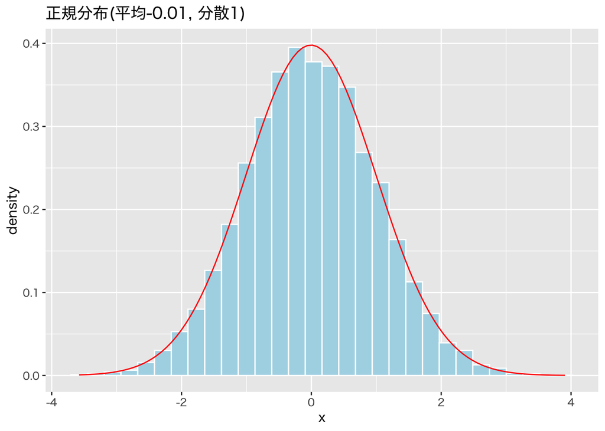

```r
mu <- mean(x)
sigma <- sd(x)
tibble(x = as.vector(x)) |>
    ggplot(aes(x = x)) +
    geom_histogram(aes(y = after_stat(density)),
                   bins = 30,
                   fill ="lightblue",
                   colour = "white") +
    geom_function(fun = dnorm,
                  args = list(mean = mu, sd = sigma),
                  colour = "red") +
    labs(title = paste0("正規分布(平均", round(mu,2),       # 2桁で四捨五入
                        ", 分散", round(sigma^2,2), ")"))
```

散布図を描くためのデータフレームは以下のようにして作ることもできる． 高次元の場合には関数を利用した方が簡単に記述できる．

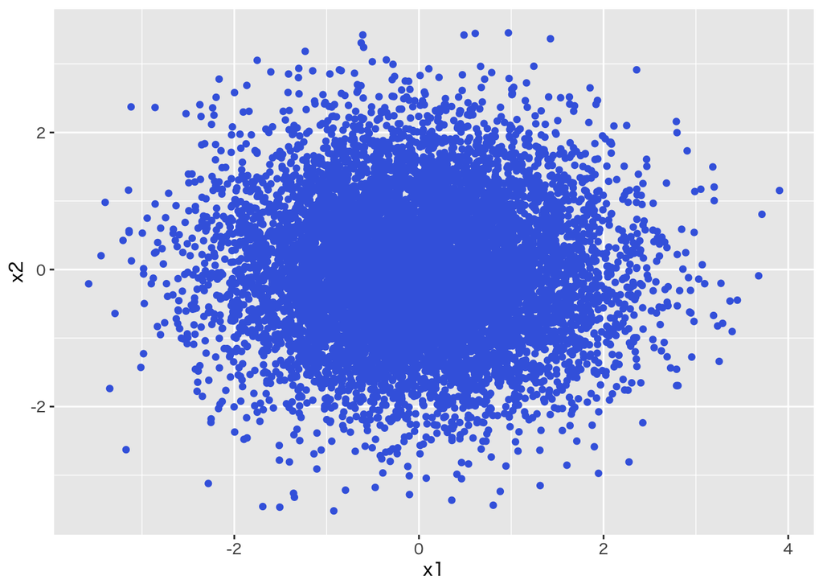

```r
x |>
    t() |>                                 # 行列を転置
    as_tibble(.name_repair = "minimal") |> # tibbleに変換，列名の修正を指示
    set_names(paste0("x", 1:2)) |>         # 列名の書き換え
    ggplot(aes(x = x1, y = x2)) +
    geom_point(colour = "royalblue")
```

## $\chi^2$ 分布

### 問題

$\chi^2$ 分布に関して以下を考察せよ．

- 標準正規分布に従う $k$ 個の独立な確率変数の二乗和は自由度 $k$ の $\chi^2$ 分布に従うことを確認しなさい．

### 解答欄

### 解答例

試行を模擬する関数を定義する．

```r
k <- 8                   # 自由度を設定
my_random <- function(){
    sum(rnorm(k)^2)}     # k個の標準正規乱数の二乗和
```

確率シミュレーションを行い，視覚化する．

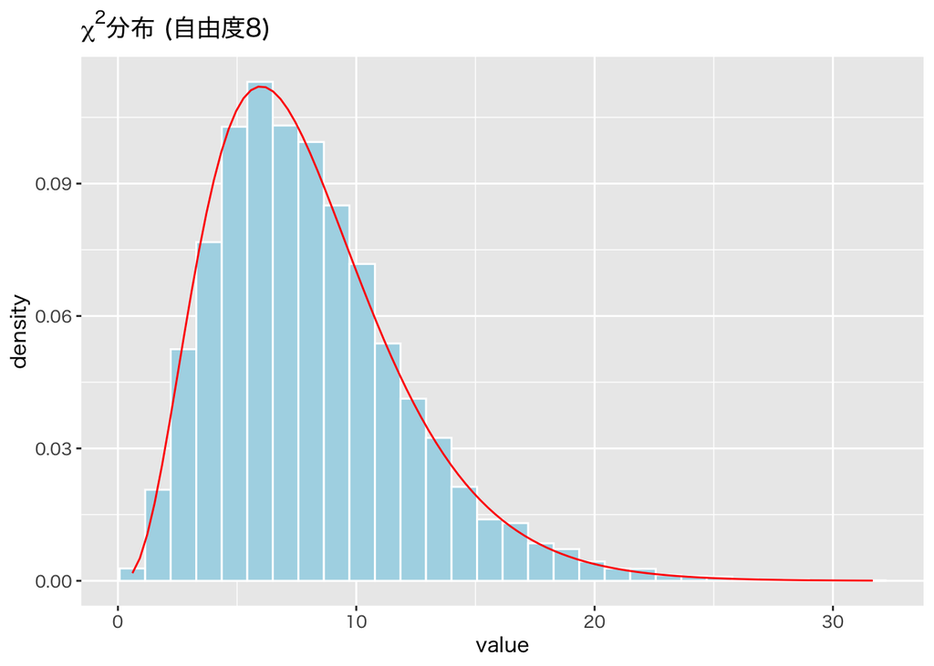

```r
mc <- 10000 # 実験回数を指定
my_data <-
    replicate(mc, my_random()) # 注で使うので保存しておく
my_data |>
    as_tibble_col() |>
    ggplot(aes(x = value)) +
    geom_histogram(aes(y = after_stat(density)),
                   bins = 30,
                   fill ="lightblue",
                   colour = "white") +
    geom_function(fun = dchisq,
                  args = list(df = k),
                  colour = "red") +
    labs(title = bquote(paste(chi^2,"分布 (自由度",.(k),")")))
```

関数 bquote() は関数 expression() と同様な働きをするが，自由度の k を .(k) で評価して取り込むことができる． 以下と表示を比較してみよう．

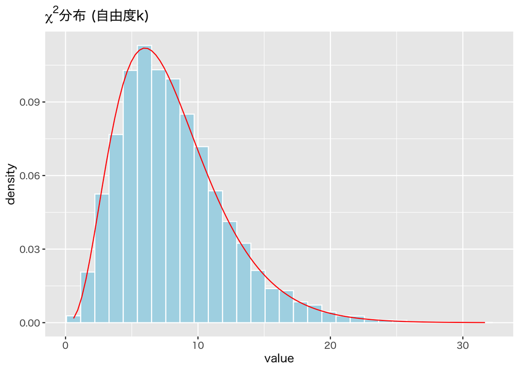

```r
my_data |>
    as_tibble_col() |>
    ggplot(aes(x = value)) +
    geom_histogram(aes(y = after_stat(density)),
                   bins = 30,
                   fill ="lightblue",
                   colour = "white") +
    geom_function(fun = dchisq,
                  args = list(df = k),
                  colour = "red") +
    labs(title = expression(paste(chi^2,"分布 (自由度",k,")"))) # この行だけ違う
```

## $t$ 分布

### 問題

$t$ 分布に関して以下を考察せよ．

- $Z$ を標準正規分布に従う確率変数，$Y$ を自由度 $k$ の $\chi^2$ 分布に従う確率変数とし，$Z,Y$ は独立であるとする． このとき確率変数
  $$\begin{equation}
  \frac{Z}{\sqrt{Y/k}}
  \end{equation}$$
  は自由度 $k$ の $t$ 分布に従うことを確認しなさい．

### 解答欄

### 解答例

試行を模擬する関数を作成する．

```r
k <- 7 # 自由度を設定
my_random <- function(){
    y <- rchisq(1, df=k) # 自由度kのカイ2乗分布
    ## y <- sum(rnorm(k)^2) # 正規乱数を用いてもよい
    z <- rnorm(1) # 標準正規乱数
    return(z/sqrt(y/k))}
```

確率シミュレーションを行い，視覚化する．

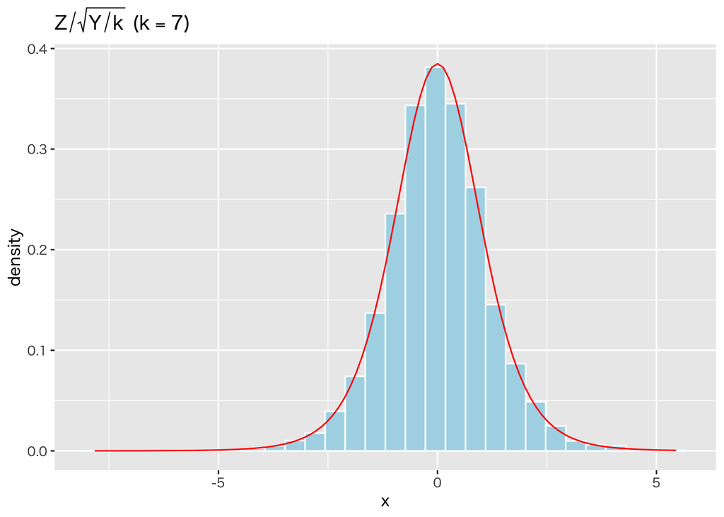

```r
mc <- 10000 # 実験回数を指定
my_data <- replicate(mc, my_random()) # Monte-Carlo実験
tibble(x = my_data) |>
    ggplot(aes(x = x)) +
    geom_histogram(aes(y = after_stat(density)),
                   bins = 30,
                   fill ="lightblue",
                   colour = "white") +
    geom_function(fun = dt,
                  args = list(df = k),
                  colour = "red") +
    labs(title = bquote(paste(Z/sqrt(Y/k)," (",k==.(k),")"))) # "="を表示するには"=="とする
```

## $F$ 分布

### 問題

$F$ 分布に関して以下を考察せよ．

- $Y_{1},Y_{2}$ をそれぞれ自由度 $k_{1},k_{2}$ の $\chi^2$ 分布に従う独立な確率変数とする． このとき, 確率変数
  $$\begin{equation}
  \frac{Y_{1}/k_{1}}{Y_{2}/k_{2}}
  \end{equation}$$
  は自由度 $k_{1},k_{2}$ の $F$ 分布に従うことを確認しなさい．

### 解答欄

### 解答例

試行を模擬する関数を作成する．

```r
k1 <- 20
k2 <- 10
my_random <- function(){
    y1 <- rchisq(1, df=k1) # 自由度20のカイ二乗分布
    y2 <- rchisq(1, df=k2) # 自由度10のカイ二乗分布
    ## y1 <- sum(rnorm(k1)^2) # 正規乱数を用いてもよい
    ## y2 <- sum(rnorm(k2)^2)
    return((y1/k1)/(y2/k2))}
```

確率シミュレーションを行い，視覚化する．

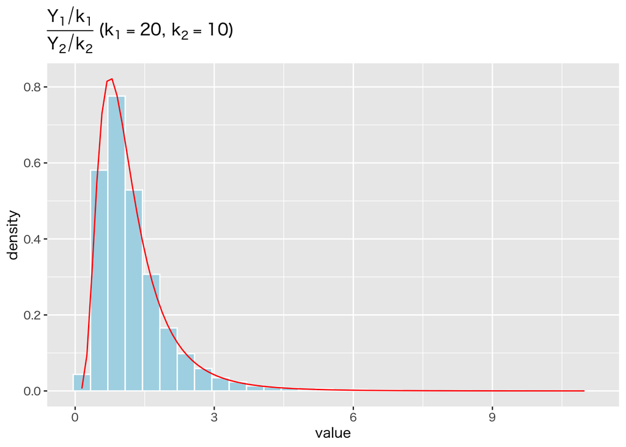

```r
mc <- 10000 # 実験回数を指定
replicate(mc, my_random()) |>
    as_tibble_col() |>
    ggplot(aes(x = value)) +
    geom_histogram(aes(y = after_stat(density)),
                   bins = 30,
                   fill ="lightblue",
                   colour = "white") +
    geom_function(fun = df,
                  args = list(df1 = k1, df2 = k2),
                  colour = "red") +
    labs(title = bquote(paste(frac(Y[1]/k[1],Y[2]/k[2]),
                              " (",k[1]==.(k1),
                              ", ",k[2]==.(k2),")")))
```

グラフの一部に着目したい場合は xlim/ylim で表示を調整することができる．

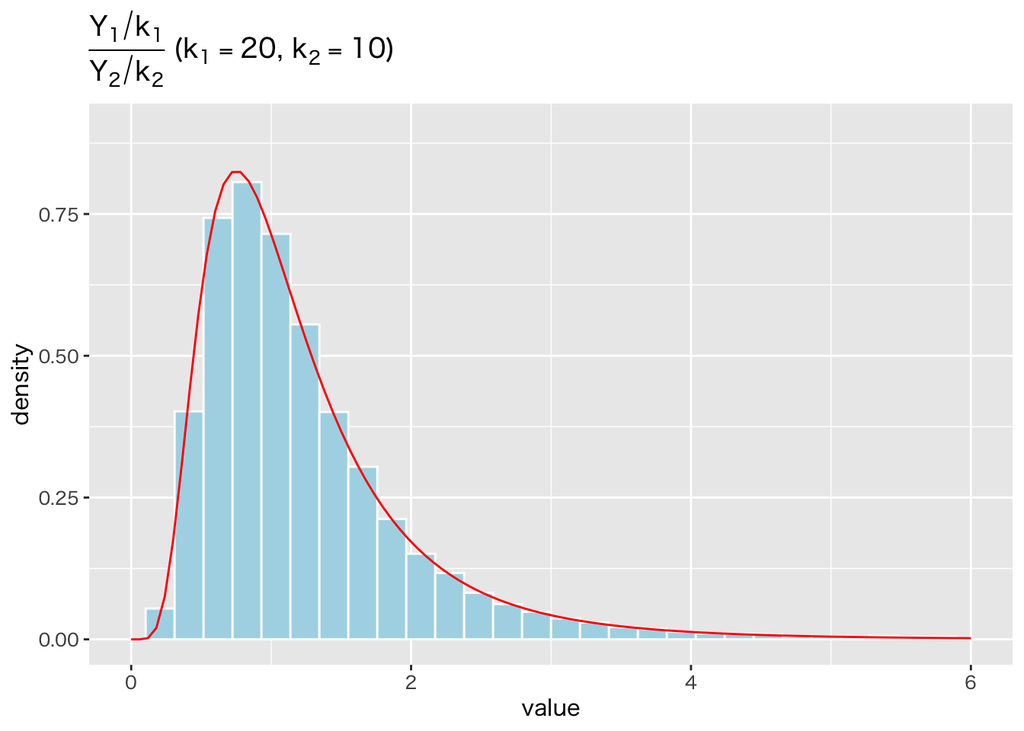

```r
last_plot() +               # 直前のプロット
    xlim(0,6) + ylim(0,0.9) # 表示領域を指定する(表示しない部分について警告が出る)
```